# EasyVisa Project

## Context:

Business communities in the United States are facing high demand for human resources, but one of the constant challenges is identifying and attracting the right talent, which is perhaps the most important element in remaining competitive. Companies in the United States look for hard-working, talented, and qualified individuals both locally as well as abroad.

The Immigration and Nationality Act (INA) of the US permits foreign workers to come to the United States to work on either a temporary or permanent basis. The act also protects US workers against adverse impacts on their wages or working conditions by ensuring US employers' compliance with statutory requirements when they hire foreign workers to fill workforce shortages. The immigration programs are administered by the Office of Foreign Labor Certification (OFLC).

OFLC processes job certification applications for employers seeking to bring foreign workers into the United States and grants certifications in those cases where employers can demonstrate that there are not sufficient US workers available to perform the work at wages that meet or exceed the wage paid for the occupation in the area of intended employment.

## Objective:

In FY 2016, the OFLC processed 775,979 employer applications for 1,699,957 positions for temporary and permanent labor certifications. This was a nine percent increase in the overall number of processed applications from the previous year. The process of reviewing every case is becoming a tedious task as the number of applicants is increasing every year.

The increasing number of applicants every year calls for a Machine Learning based solution that can help in shortlisting the candidates having higher chances of VISA approval. OFLC has hired your firm EasyVisa for data-driven solutions. You as a data scientist have to analyze the data provided and, with the help of a classification model:

- Facilitate the process of visa approvals.
- Recommend a suitable profile for the applicants for whom the visa should be certified or denied based on the drivers that significantly influence the case status.

## Importing necessary libraries and data

```python
# Libraries to help with reading and manipulating data
import numpy as np
import pandas as pd

# Libraries to help with data visualization
import seaborn as sns
import matplotlib.pyplot as plt
%matplotlib inline

# Library to help with statistical analysis
import scipy.stats as stats

# split the data into train and test
from sklearn.model_selection import train_test_split

# to build linear regression_model
import statsmodels.api as sm

# to check model performance
from sklearn.metrics import mean_absolute_error, mean_squared_error, r2_score

# To build model for prediction
import statsmodels.stats.api as sms
from statsmodels.stats.outliers_influence import variance_inflation_factor
import statsmodels.api as sm
from statsmodels.tools.tools import add_constant
from sklearn.linear_model import LogisticRegression
from sklearn.tree import DecisionTreeClassifier
from sklearn import tree
from sklearn import metrics

# To get diferent metric scores
from sklearn.metrics import (
    f1_score,
    accuracy_score,
    recall_score,
    precision_score,
    confusion_matrix,
    roc_auc_score,
    ConfusionMatrixDisplay,
    precision_recall_curve,
    roc_curve,
)
```

```python
# mount the Google Colab Drive
from google.colab import drive
drive.mount('/content/drive')
```

## Data Overview

- Observations
- Sanity checks

```python
df_original = pd.read_csv('/content/drive/MyDrive/PGP-DS_UT/5-Ensemble_Techniques/Project_5/EasyVisa.csv')
# returns the first 5 rows
df = df_original.copy()
df.head()
```

|  | case_id | continent | education_of_employee | has_job_experience | requires_job_training | no_of_employees | yr_of_estab | region_of_employment | prevailing_wage | unit_of_wage | full_time_position | case_status |
| --- | --- | --- | --- | --- | --- | --- | --- | --- | --- | --- | --- | --- |
| 0 | EZYV01 | Asia | High School | N | N | 14513 | 2007 | West | 592.2029 | Hour | Y | Denied |
| 1 | EZYV02 | Asia | Master's | Y | N | 2412 | 2002 | Northeast | 83425.6500 | Year | Y | Certified |
| 2 | EZYV03 | Asia | Bachelor's | N | Y | 44444 | 2008 | West | 122996.8600 | Year | Y | Denied |
| 3 | EZYV04 | Asia | Bachelor's | N | N | 98 | 1897 | West | 83434.0300 | Year | Y | Denied |
| 4 | EZYV05 | Africa | Master's | Y | N | 1082 | 2005 | South | 149907.3900 | Year | Y | Certified |

**Data Description**

- `case_id`: ID of each visa application
- `continent`: Information of continent the employee
- `education_of_employee`: Information of education of the employee
- `has_job_experience`: Does the employee has any job experience? Y= Yes; N = No
- `requires_job_training`: Does the employee require any job training? Y = Yes; N = No
- `no_of_employees`: Number of employees in the employer's company
- `yr_of_estab`: Year in which the employer's company was established
- `region_of_employment`: Information of foreign worker's intended region of employment in the US.
- `prevailing_wage`: Average wage paid to similarly employed workers in a specific occupation in the area of intended employment.
- `unit_of_wage`: Unit of prevailing wage. Values include Hourly, Weekly, Monthly, and Yearly.
- `full_time_position`: Is the position of work full-time? Y = Full Time Position; N = Part Time Position
- `case_status`: Flag indicating if the Visa was certified or denied

```python
df.shape
```

```
(25480, 12)
```

```python
df.info()
```

```
<class 'pandas.core.frame.DataFrame'>
RangeIndex: 25480 entries, 0 to 25479
Data columns (total 12 columns):
 #   Column                 Non-Null Count  Dtype
---  ------                 --------------  -----
 0   case_id                25480 non-null  object
 1   continent              25480 non-null  object
 2   education_of_employee  25480 non-null  object
 3   has_job_experience     25480 non-null  object
 4   requires_job_training  25480 non-null  object
 5   no_of_employees        25480 non-null  int64
 6   yr_of_estab            25480 non-null  int64
 7   region_of_employment   25480 non-null  object
 8   prevailing_wage        25480 non-null  float64
 9   unit_of_wage           25480 non-null  object
 10  full_time_position     25480 non-null  object
 11  case_status            25480 non-null  object
dtypes: float64(1), int64(2), object(9)
memory usage: 2.3+ MB
```

```python
#let's see which features have missing values and how many they have
df.isna().sum()
```

```
case_id                  0
continent                0
education_of_employee    0
has_job_experience       0
requires_job_training    0
no_of_employees          0
yr_of_estab              0
region_of_employment     0
prevailing_wage          0
unit_of_wage             0
full_time_position       0
case_status              0
dtype: int64
```

```python
df['case_id'].duplicated().sum()
```

```
0
```

```python
df.describe().T
```

|  | count | mean | std | min | 25% | 50% | 75% | max |
| --- | --- | --- | --- | --- | --- | --- | --- | --- |
| no_of_employees | 25480.0 | 5667.043210 | 22877.928848 | -26.0000 | 1022.00 | 2109.00 | 3504.0000 | 602069.00 |
| yr_of_estab | 25480.0 | 1979.409929 | 42.366929 | 1800.0000 | 1976.00 | 1997.00 | 2005.0000 | 2016.00 |
| prevailing_wage | 25480.0 | 74455.814592 | 52815.942327 | 2.1367 | 34015.48 | 70308.21 | 107735.5125 | 319210.27 |

```python
df.describe(include = 'O').T
```

|  | count | unique | top | freq |
| --- | --- | --- | --- | --- |
| case_id | 25480 | 25480 | EZYV01 | 1 |
| continent | 25480 | 6 | Asia | 16861 |
| education_of_employee | 25480 | 4 | Bachelor's | 10234 |
| has_job_experience | 25480 | 2 | Y | 14802 |
| requires_job_training | 25480 | 2 | N | 22525 |
| region_of_employment | 25480 | 5 | Northeast | 7195 |
| unit_of_wage | 25480 | 4 | Year | 22962 |
| full_time_position | 25480 | 2 | Y | 22773 |
| case_status | 25480 | 2 | Certified | 17018 |

```python
df.nunique()
```

```
case_id                  25480
continent                    6
education_of_employee        4
has_job_experience           2
requires_job_training        2
no_of_employees           7105
yr_of_estab                199
region_of_employment         5
prevailing_wage          25454
unit_of_wage                 4
full_time_position           2
case_status                  2
dtype: int64
```

## Exploratory Data Analysis (EDA)

- EDA is an important part of any project involving data.
- It is important to investigate and understand the data better before building a model with it.
- A few questions have been mentioned below which will help you approach the analysis in the right manner and generate insights from the data.
- A thorough analysis of the data, in addition to the questions mentioned below, should be done.

**Leading Questions**:

1. Those with higher education may want to travel abroad for a well-paid job. Does education play a role in Visa certification?
2. How does the visa status vary across different continents?
3. Experienced professionals might look abroad for opportunities to improve their lifestyles and career development. Does work experience influence visa status?
4. In the United States, employees are paid at different intervals. Which pay unit is most likely to be certified for a visa?
5. The US government has established a prevailing wage to protect local talent and foreign workers. How does the visa status change with the prevailing wage?

### Univariate - Continuous Features

These can be understood as features that are not categorical in their nature. Even if they are labeled as a number, these features operate under a continuous scale. I will not include `case_id` as part of the EDA process, as it's an identifier feature.

```python
#create a funciton to plot the boxplot and histogram of our features
def histogram_boxplot(data, column_name):
    # Create a figure with two subplots stacked vertically
    fig, (ax1, ax2) = plt.subplots(2, 1, figsize=(16, 8))

    # Plot the boxplot on the first subplot
    sns.boxplot(x=data[column_name], ax=ax1)
    ax1.set_title(f'Boxplot for: {column_name}')

    # Plot the histogram on the second subplot
    sns.histplot(data[column_name], kde=True, ax=ax2)
    ax2.set_title(f'Histogram for: {column_name}')

    # Adjust layout
    plt.tight_layout()

    # Show the plot
    plt.show()
```

#### No. of Employees

Number of employees in the employer's company

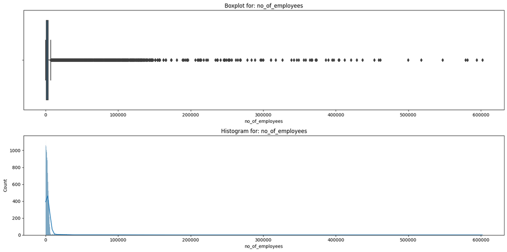

```python
histogram_boxplot(df, 'no_of_employees')
```

#### Year of Establishment

Year in which the employer's company was established

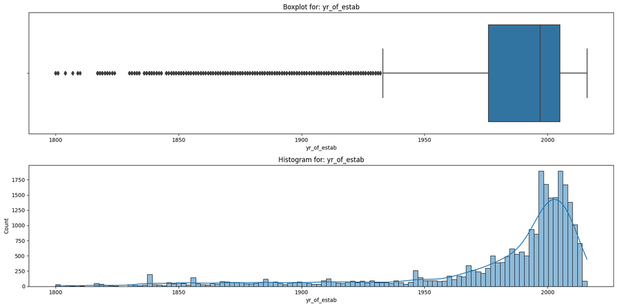

```python
histogram_boxplot(df, 'yr_of_estab')
```

#### Prevailing Wage

Average wage paid to similarly employed workers in a specific occupation in the area of intended employment.

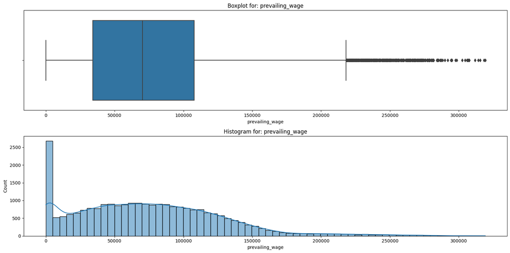

```python
histogram_boxplot(df, 'prevailing_wage')
```

**Observations**

- We have companies of all sizes ranging from some that have no employees to up to ~600K. However, we can see that some companies have a negative amount of employees, which we would need to clean so that it's 0. We cannot have negative employees for a company.
- Half of the companies were founded between 1976 and 2005 with some founded in the 1800s
- A significant number of employees have a low salary, which raises the question whether the salary recorded was on a per unit basis or is it all annualized.

### Univariate - Categorical Features

Now let's look at the remaining features to have a better understanding of how these categories are distributed

```python
# function to create labeled barplots
def labeled_barplot(data, feature, perc=False, n=None):
    """
    Barplot with percentage at the top

    data: dataframe
    feature: dataframe column
    perc: whether to display percentages instead of count (default is False)
    n: displays the top n category levels (default is None, i.e., display all levels)
    """

    total = len(data[feature])  # length of the column
    count = data[feature].nunique()
    if n is None:
        plt.figure(figsize=(count+2, 5))
    else:
        plt.figure(figsize=(n + 2, 5))

    plt.xticks(rotation=45, fontsize=15)
    plt.title(f"Barplot of {feature}")
    ax = sns.countplot(
        data=data,
        x=feature,
        palette="Paired",
        #order=data[feature].value_counts().index[:n],
    )

    for p in ax.patches:
        if perc == True:
            label = "{:.1f}%".format(
                100 * p.get_height() / total
            )  # percentage of each class of the category
        else:
            label = p.get_height()  # count of each level of the category

        x = p.get_x() + p.get_width() / 2  # width of the plot
        y = p.get_height()  # height of the plot

        ax.annotate(
            label,
            (x, y),
            ha="center",
            va="center",
            size=12,
            xytext=(0, 5),
            textcoords="offset points",
        )  # annotate the percentage
    plt.show()  # show the plot
```

```python
def proportion_values(data,feature):
  return(data.groupby(feature)[feature].count()/len(data))
```

#### Case_id

Given that `case_id` are unique identifiers, for forecasting and anlaytical purposes, they're not relevant. To that end, we won't plot their distribution.

#### Continent

Information of continent from where the employee is applying for the visa from

```python
df.groupby('continent')['continent'].count()/len(df)
```

```
continent
Africa           0.021625
Asia             0.661735
Europe           0.146468
North America    0.129199
Oceania          0.007535
South America    0.033438
Name: continent, dtype: float64
```

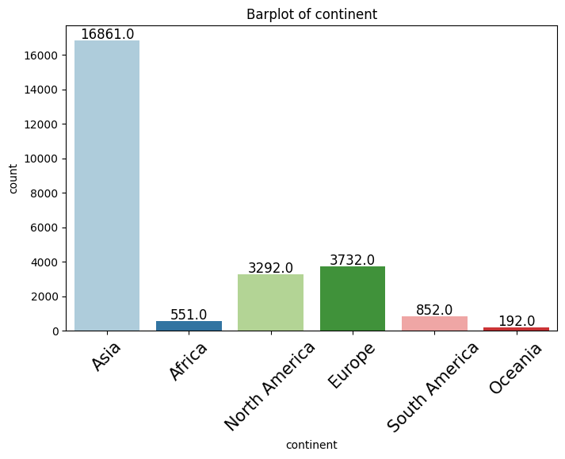

```python
labeled_barplot(df, 'continent')
```

#### Employee Education

Label of the maximum level of education the applicant has achieved

```python
df.groupby('education_of_employee')['education_of_employee'].count()/len(df)
```

```
education_of_employee
Bachelor's     0.401648
Doctorate      0.086028
High School    0.134223
Master's       0.378100
Name: education_of_employee, dtype: float64
```

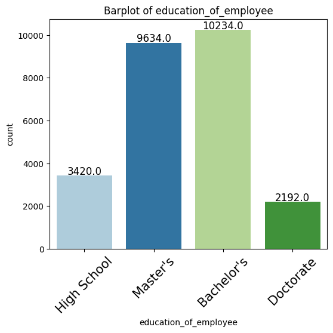

```python
labeled_barplot(df, 'education_of_employee')
```

#### Job Experience

Identifier whether the applicant has or does not have job experience

```python
df.groupby('has_job_experience')['has_job_experience'].count()/len(df)
```

```
has_job_experience
N    0.419074
Y    0.580926
Name: has_job_experience, dtype: float64
```

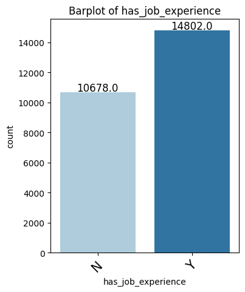

```python
labeled_barplot(df, 'has_job_experience')
```

#### Requires Job Training

Label indicating whether the applicant requires job training

```python
df.groupby('requires_job_training')['requires_job_training'].count()/len(df)
```

```
requires_job_training
N    0.884027
Y    0.115973
Name: requires_job_training, dtype: float64
```

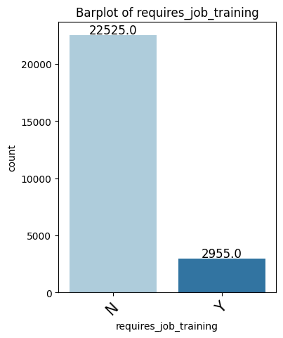

```python
labeled_barplot(df, 'requires_job_training')
```

#### Region of Employemnt

Information of foreign worker's intended region of employment in the US.

```python
df.groupby('region_of_employment')['region_of_employment'].count()/len(df)
```

```
region_of_employment
Island       0.014717
Midwest      0.169035
Northeast    0.282378
South        0.275392
West         0.258477
Name: region_of_employment, dtype: float64
```

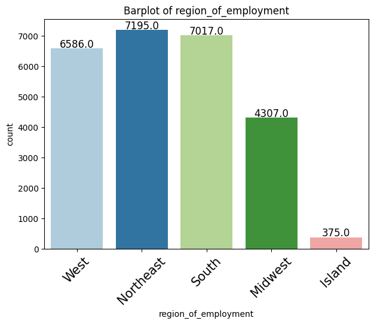

```python
labeled_barplot(df, 'region_of_employment')
```

#### Unit of Wage

Prevailing employment payment schedule to calculate salary

```python
df.groupby('unit_of_wage')['unit_of_wage'].count()/len(df)
```

```
unit_of_wage
Hour     0.084655
Month    0.003493
Week     0.010675
Year     0.901177
Name: unit_of_wage, dtype: float64
```

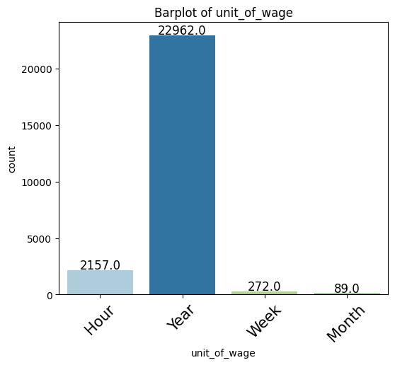

```python
labeled_barplot(df, 'unit_of_wage')
```

#### Full time position

Indicates whether the role is full time or not

```python
df.groupby('full_time_position')['full_time_position'].count()/len(df)
```

```
full_time_position
N    0.10624
Y    0.89376
Name: full_time_position, dtype: float64
```

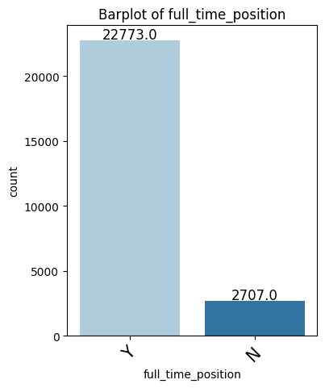

```python
labeled_barplot(df, 'full_time_position')
```

#### Case status (Target)

Flag indicating if the Visa was certified or denied

```python
df.groupby('case_status')['case_status'].count()/len(df)
```

```
case_status
Certified    0.667896
Denied       0.332104
Name: case_status, dtype: float64
```

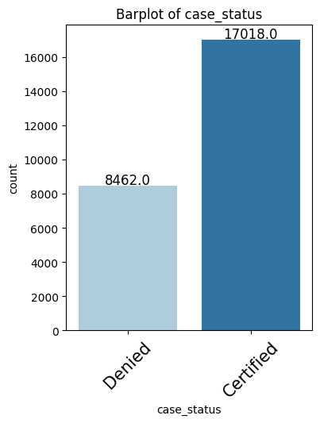

```python
labeled_barplot(df, 'case_status')
```

**Observations:**

- About 2/3 of visa applications were certified
- The majority of wages (~90%) are calculated on a yearly basis, the rest are hourly, weekly or by month.
- Most employees (~88%) don't require training on the job
- The vast majority of applicants come from Asia
- Applicants are evenly distributed to where they are planning to work, with the exception of not many going to the Islands or the Midwest
- There is a relatively even distribution of applicants that have job experience.
- In addition, there is a surprisngily large number of visa applicants that have a doctorate degree (~8%).

### Bivaraite Analysis

```python
def stacked_barplot(df, predictor, target):
    """
    Analyzes the relationship between two categorical features using stacked bar plots
    with data labels and prints tables of grouped values.

    Parameters:
    df (pd.DataFrame): The DataFrame containing the data.
    predictor (str): The name of the predictor categorical column.
    target (str): The name of the target categorical column.
    """
    # Cross-tabulation for count and proportion
    count_ctab = pd.crosstab(df[predictor], df[target])
    prop_ctab = pd.crosstab(df[predictor], df[target], normalize='index')

    # Sorting by the first target category (assumed positive)
    prop_ctab = prop_ctab.sort_values(by=prop_ctab.columns[0], ascending=True)

    # Displaying the count table
    print("Count Table:")
    display(count_ctab)

    print("-" * 120)

    # Stacked bar plot with data labels
    ax = prop_ctab.plot(kind='bar', stacked=True, figsize=(10, 6))
    plt.title(f'Stacked Bar Plot of {predictor} vs {target}')
    plt.xlabel(predictor)
    plt.ylabel('Proportion')
    plt.legend(title=target, bbox_to_anchor=(1.05, 1), loc='upper left')

    # Adding data labels
    for bars in ax.containers:
        ax.bar_label(bars, fmt=lambda x: f'{x * 100:.2f}%',label_type='center')

    plt.show()
```

```python
# def stacked_barplot(data, predictor, target):
#     """
#     Print the category counts and plot a stacked bar chart

#     data: dataframe
#     predictor: independent variable
#     target: target variable
#     """
#     count = data[predictor].nunique()
#     sorter = data[target].value_counts().index[-1]
#     tab1 = pd.crosstab(data[predictor], data[target], margins=True).sort_values(
#         by=sorter, ascending=False
#     )
#     print(tab1)

#     print("-" * 120)
#     tab = pd.crosstab(data[predictor], data[target], normalize="index").sort_values(
#         by=sorter, ascending=False
#     )

#     ax = tab.plot(kind="bar", stacked=True, figsize=(count + 5, 5))

#     # Add data labels to each bar segment
#     for p in ax.patches:
#         width, height = p.get_width(), p.get_height()
#         x, y = p.get_xy()
#         ax.annotate(f'{height:.2%}', (x + width/2, y + height/2), ha='center', va='center', xytext=(0, 10), textcoords='offset points')

#     plt.legend(
#         loc="lower left", frameon=False,
#     )

#     plt.legend(loc="upper left", bbox_to_anchor=(1, 1))
#     plt.show()
```

```python
### function to plot distributions wrt target

def distribution_plot_wrt_target(data, predictor, target):

    fig, axs = plt.subplots(2, 2, figsize=(12, 10))

    target_uniq = data[target].unique()

    axs[0, 0].set_title("Distribution of target for target=" + str(target_uniq[0]))
    sns.histplot(
        data=data[data[target] == target_uniq[0]],
        x=predictor,
        kde=True,
        ax=axs[0, 0],
        color="teal",
        stat="density",
    )

    axs[0, 1].set_title("Distribution of target for target=" + str(target_uniq[1]))
    sns.histplot(
        data=data[data[target] == target_uniq[1]],
        x=predictor,
        kde=True,
        ax=axs[0, 1],
        color="orange",
        stat="density",
    )

    axs[1, 0].set_title("Boxplot w.r.t target")
    sns.boxplot(data=data, x=target, y=predictor, ax=axs[1, 0], palette="gist_rainbow")

    axs[1, 1].set_title("Boxplot (without outliers) w.r.t target")
    sns.boxplot(
        data=data,
        x=target,
        y=predictor,
        ax=axs[1, 1],
        showfliers=False,
        palette="gist_rainbow",
    )

    plt.tight_layout()
    plt.show()
```

Correlation amongst all numerical features

```python
# creating a list of numerical columns
num_cols = df.select_dtypes(include=np.number).columns.tolist()
num_cols
```

```
['no_of_employees', 'yr_of_estab', 'prevailing_wage']
```

```python
# for the purpose of this analysis, let's also look at non-numerical features
obj_cols = df.select_dtypes(include='O').columns.tolist()
obj_cols
```

```
['case_id',
 'continent',
 'education_of_employee',
 'has_job_experience',
 'requires_job_training',
 'region_of_employment',
 'unit_of_wage',
 'full_time_position',
 'case_status']
```

#### Correlation check

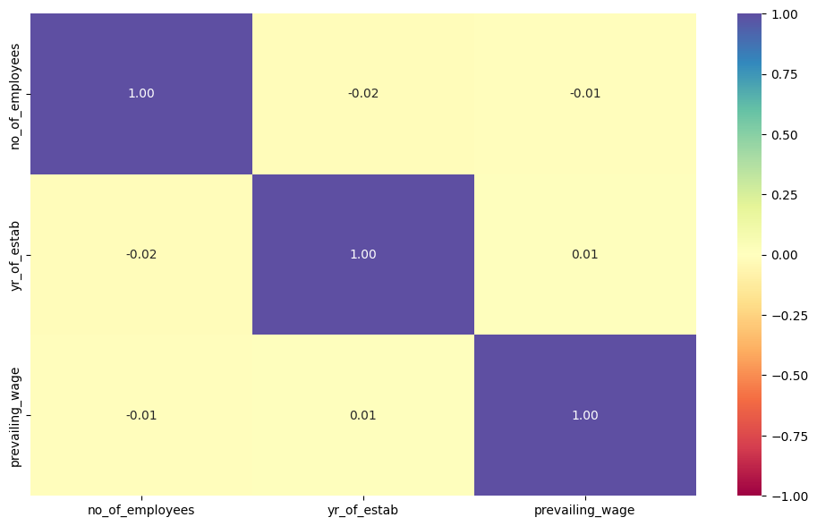

```python
# drop numerical features that are categorical in nature

plt.figure(figsize=(12, 7))
sns.heatmap(
    df[num_cols].corr(), annot=True, vmin=-1, vmax=1, fmt=".2f", cmap="Spectral"
)
plt.show()
```

#### Education vs. Case Status

Applicants with a higher education may want to work abroad to increase their income potential. Does education play a role in Visa certification?

```
Count Table:
```

| case_status education_of_employee | Certified | Denied |
| --- | --- | --- |
| Bachelor's | 6367 | 3867 |
| Doctorate | 1912 | 280 |
| High School | 1164 | 2256 |
| Master's | 7575 | 2059 |

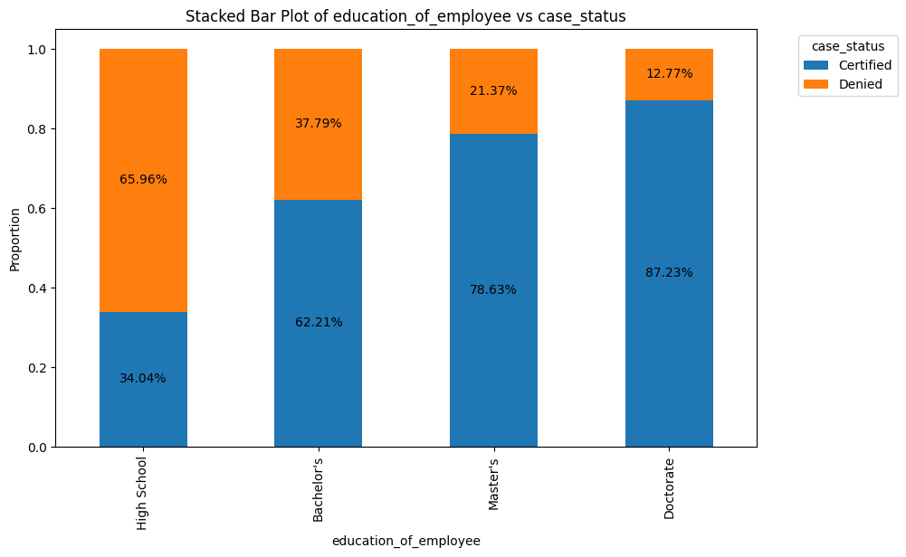

```python
stacked_barplot(df, 'education_of_employee', 'case_status')
```

#### Continent vs. Case Status

```
Count Table:
```

| case_status continent | Certified | Denied |
| --- | --- | --- |
| Africa | 397 | 154 |
| Asia | 11012 | 5849 |
| Europe | 2957 | 775 |
| North America | 2037 | 1255 |
| Oceania | 122 | 70 |
| South America | 493 | 359 |

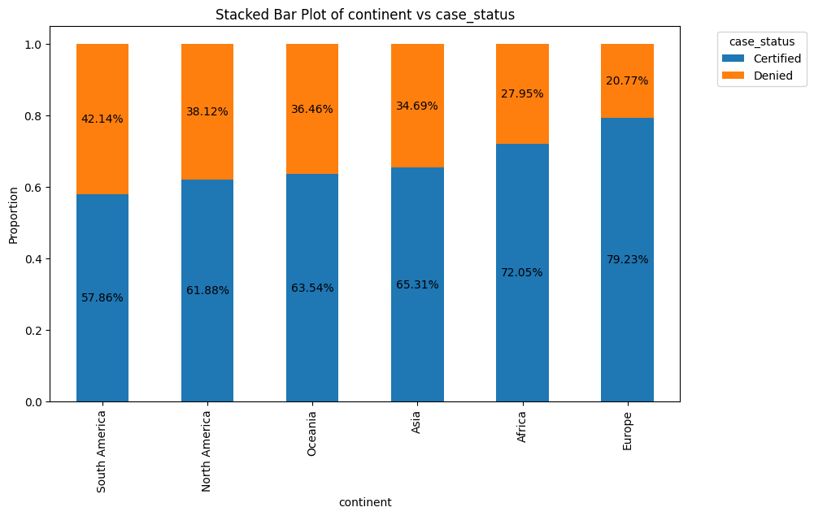

```python
stacked_barplot(df, 'continent', 'case_status')
```

#### Job Experience vs. Case Status

```
Count Table:
```

| case_status has_job_experience | Certified | Denied |
| --- | --- | --- |
| N | 5994 | 4684 |
| Y | 11024 | 3778 |

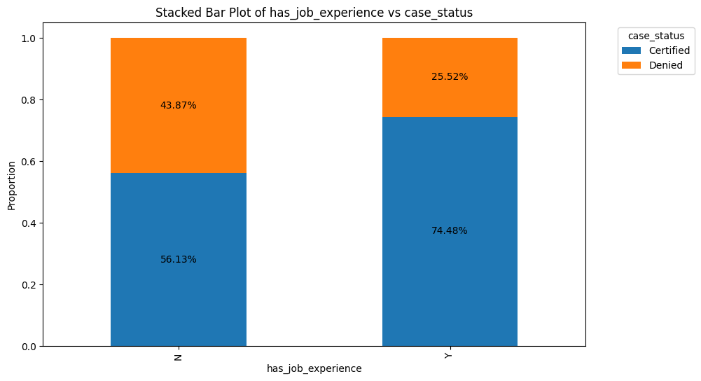

```python
stacked_barplot(df, 'has_job_experience', 'case_status')
```

#### Unit of Wage vs. Case Status

```
Count Table:
```

| case_status unit_of_wage | Certified | Denied |
| --- | --- | --- |
| Hour | 747 | 1410 |
| Month | 55 | 34 |
| Week | 169 | 103 |
| Year | 16047 | 6915 |

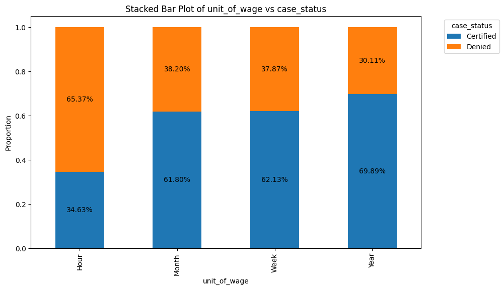

```python
stacked_barplot(df, 'unit_of_wage', 'case_status')
```

**Obesrvation** Interesting to note that employees with an annual salary tend to be more likely to be approved for a visa. In addition, hourly employees tend to get rejected more. For months and weeks, we might not have sufficient data to draw inferences.

#### Prevailing Wage vs. Case Status

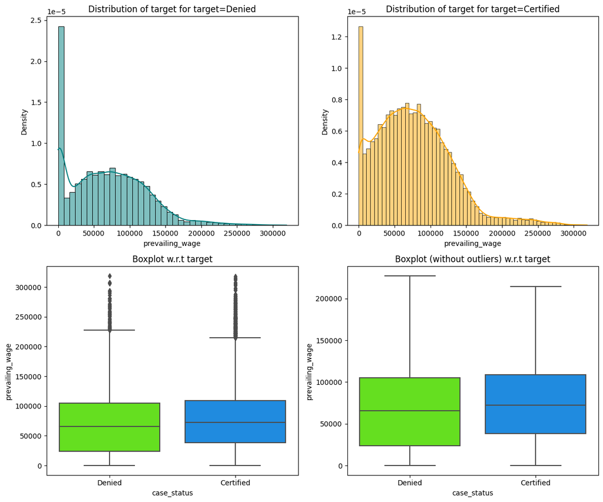

```python
distribution_plot_wrt_target(df, 'prevailing_wage', 'case_status')
```

There appears to be a large amount of instances of employers reporting wages close to 0. This I presume is due to the fact that wages are reported by the unit of wage. So let's see how that looks like

```python
df.groupby('unit_of_wage')['prevailing_wage'].mean()
```

```
unit_of_wage
Hour       414.570513
Month    87592.864045
Week     85606.820515
Year     81228.077133
Name: prevailing_wage, dtype: float64
```

```python
### function to plot distributions wrt target

def distribution_wage_unit(data, predictor, target):

    fig, axs = plt.subplots(2, 2, figsize=(20, 10))
    target_uniq = data[target].unique()

    axs[0, 0].set_title("Distribution of Prevailing Wage for Unit of Wage=" + str(target_uniq[0]))
    sns.histplot(
        data=data[data[target] == target_uniq[0]],
        x=predictor,
        kde=True,
        ax=axs[0, 0],
        color="teal",
        stat="density",
    )

    axs[0, 1].set_title("Distribution of Prevailing Wage for Unit of Wage=" + str(target_uniq[1]))
    sns.histplot(
        data=data[data[target] == target_uniq[1]],
        x=predictor,
        kde=True,
        ax=axs[0, 1],
        color="orange",
        stat="density",
    )

    axs[1, 0].set_title("Distribution of Prevailing Wage for Unit of Wage=" + str(target_uniq[2]))
    sns.histplot(
        data=data[data[target] == target_uniq[2]],
        x=predictor,
        kde=True,
        ax=axs[1, 0],
        color="blue",
        stat="density",
    )

    axs[1, 1].set_title("Distribution of Prevailing Wage for Unit of Wage=" + str(target_uniq[3]))
    sns.histplot(
        data=data[data[target] == target_uniq[3]],
        x=predictor,
        kde=True,
        ax=axs[1, 1],
        color="purple",
        stat="density",
    )

    plt.tight_layout()
    plt.show()
```

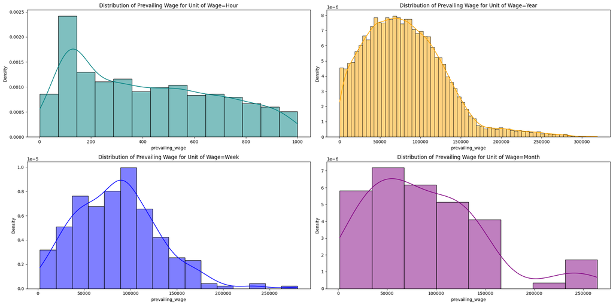

```python
distribution_wage_unit(df,'prevailing_wage','unit_of_wage')
#sns.displot(df[df['unit_of_wage']=='Hour']['prevailing_wage'], kde = True)
```

##### Distribution of Target for Unit of Wage = Year

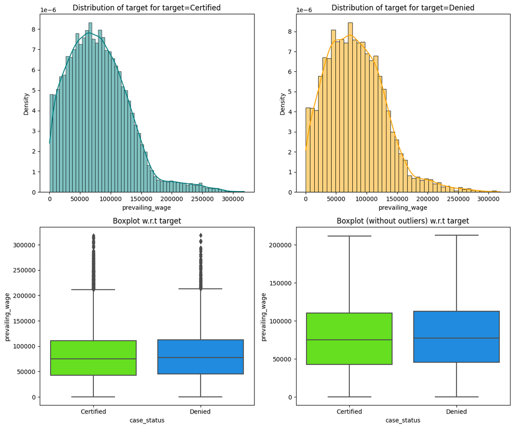

```python
#let's look at the relationship between prevailing wage and case status only for the unit of wage in Years
distribution_plot_wrt_target(df[df['unit_of_wage']=='Year'], 'prevailing_wage', 'case_status')
```

There appears to be no relationship between the pervailing wage and whether the visa applicant will get approved or denied

#### No. of Employees vs. Case Status

Does the company size of where the visa applicant is applying for affect their visa approval chances?

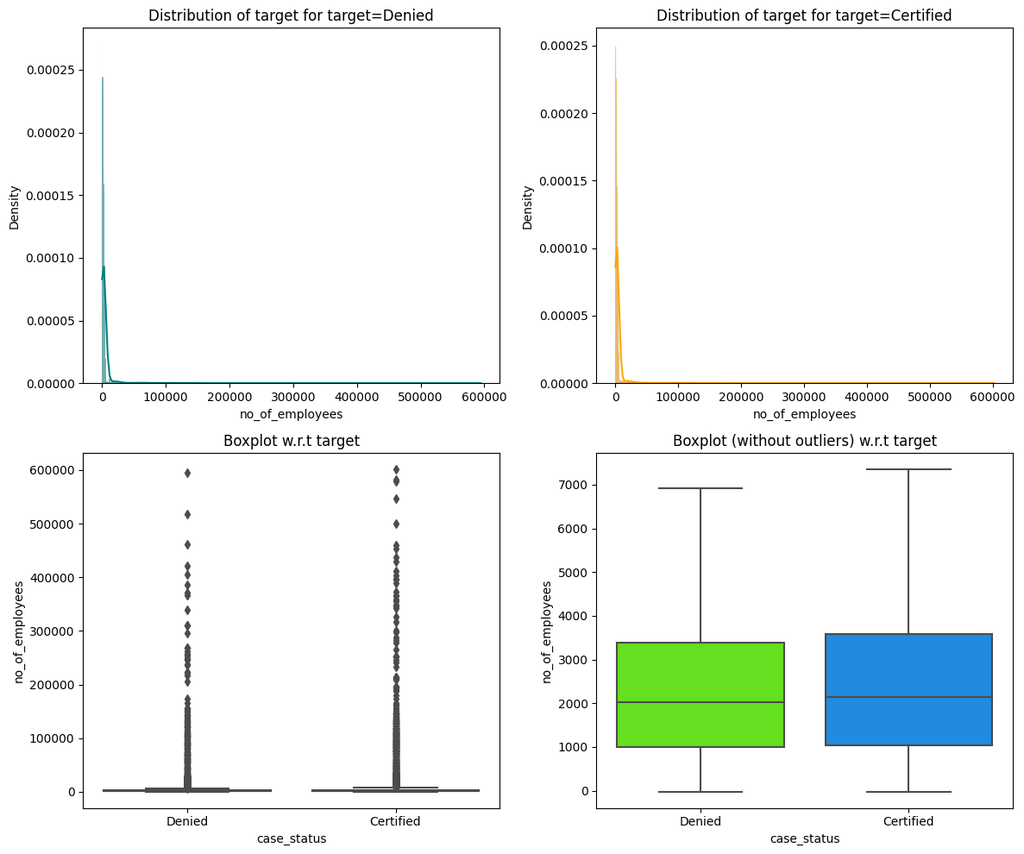

```python
distribution_plot_wrt_target(df, 'no_of_employees', 'case_status')
```

Althuogh we have a lot of outliers, we can see that the company size does not appear to have an impact on case status

#### Education vs. Region of Employment

```
Count Table:
```

| education_of_employee region_of_employment | Bachelor's | Doctorate | High School | Master's |
| --- | --- | --- | --- | --- |
| Island | 129 | 25 | 60 | 161 |
| Midwest | 1315 | 256 | 736 | 2000 |
| Northeast | 2874 | 656 | 905 | 2760 |
| South | 2991 | 541 | 934 | 2551 |
| West | 2925 | 714 | 785 | 2162 |

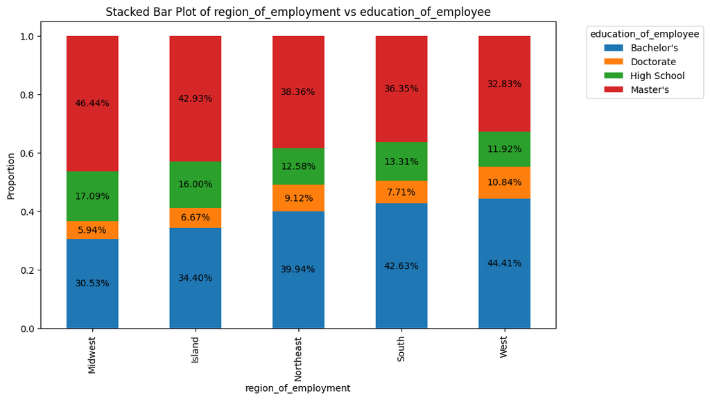

```python
stacked_barplot(df, 'region_of_employment', 'education_of_employee')
```

```
Count Table:
```

| education_of_employee continent | Bachelor's | Doctorate | High School | Master's |
| --- | --- | --- | --- | --- |
| Africa | 143 | 54 | 66 | 288 |
| Asia | 7168 | 923 | 2290 | 6480 |
| Europe | 1299 | 846 | 490 | 1097 |
| North America | 1225 | 258 | 401 | 1408 |
| Oceania | 66 | 22 | 36 | 68 |
| South America | 333 | 89 | 137 | 293 |

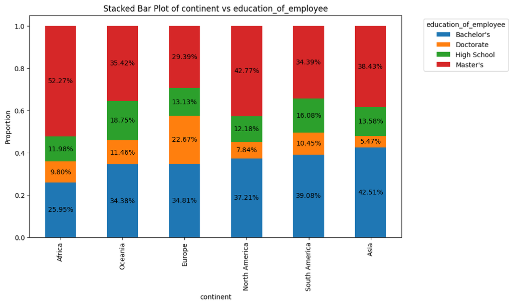

```python
stacked_barplot(df, 'continent', 'education_of_employee')
```

#### Region of Employment vs. Case Status

Does moving to a specific region have an impact on whether one's visa application will be accepted or rejected?

```
Count Table:
```

| case_status region_of_employment | Certified | Denied |
| --- | --- | --- |
| Island | 226 | 149 |
| Midwest | 3253 | 1054 |
| Northeast | 4526 | 2669 |
| South | 4913 | 2104 |
| West | 4100 | 2486 |

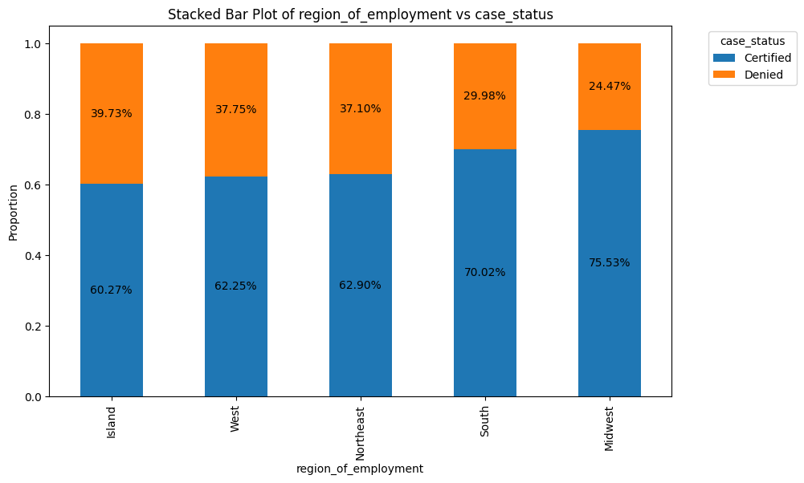

```python
stacked_barplot(df, 'region_of_employment', 'case_status')
```

## Data Preprocessing

#### 1. Missing Values

```python
#let's see if there are any missing values
df.isna().sum()
```

```
case_id                  0
continent                0
education_of_employee    0
has_job_experience       0
requires_job_training    0
no_of_employees          0
yr_of_estab              0
region_of_employment     0
prevailing_wage          0
unit_of_wage             0
full_time_position       0
case_status              0
dtype: int64
```

#### 2. Outlier Detection

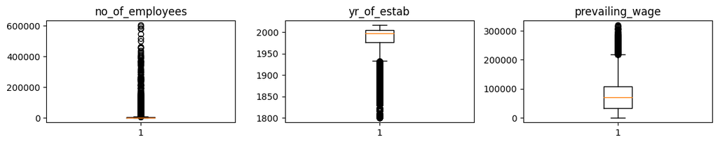

```python
# outlier detection using boxplot
numeric_columns = df.select_dtypes(include=np.number).columns.tolist()

plt.figure(figsize=(15, 12))

for i, variable in enumerate(numeric_columns):
    plt.subplot(6, 4, i + 1)
    plt.boxplot(df[variable], whis=1.5)
    plt.tight_layout()
    plt.title(variable)

plt.show()
```

```python
df.groupby('unit_of_wage')['prevailing_wage'].mean()
```

```
unit_of_wage
Hour       414.570513
Month    87592.864045
Week     85606.820515
Year     81228.077133
Name: prevailing_wage, dtype: float64
```

At first glance, it appears that our wages are indeed annualized, as they're quite similar for Month, Week, and Year. It would be important to corroborate with the team as to why we're seeing such a discrepancy. For now, we will leave them as is for the analysis.

#### 3. Feature Engineering

To do so, we will first split our dataset into train and test as follows

```python
from sklearn.model_selection import train_test_split
from sklearn.preprocessing import StandardScaler, OneHotEncoder

#convert target to binary classifcation
df['case_status'] = df['case_status'].apply(lambda x : 1 if x=='Certified' else 0)

# Defining the features and target variable
X = df.drop(['case_id', 'case_status'], axis=1)  # Dropping the 'case_id' as it's a unique identifier and 'case_status' as it's the target
y = df['case_status']
```

##### Convert year of estb. to age of company

```python
#create a new feature called company age
X['company_age'] = 2023 - X['yr_of_estab']
X = X.drop('yr_of_estab', axis = 1)
```

```python
X.head()
```

|  | continent | education_of_employee | has_job_experience | requires_job_training | no_of_employees | region_of_employment | prevailing_wage | unit_of_wage | full_time_position | company_age |
| --- | --- | --- | --- | --- | --- | --- | --- | --- | --- | --- |
| 0 | Asia | High School | N | N | 14513 | West | 592.2029 | Hour | Y | 16 |
| 1 | Asia | Master's | Y | N | 2412 | Northeast | 83425.6500 | Year | Y | 21 |
| 2 | Asia | Bachelor's | N | Y | 44444 | West | 122996.8600 | Year | Y | 15 |
| 3 | Asia | Bachelor's | N | N | 98 | West | 83434.0300 | Year | Y | 126 |
| 4 | Africa | Master's | Y | N | 1082 | South | 149907.3900 | Year | Y | 18 |

```python
y.value_counts()
```

```
1    17018
0     8462
Name: case_status, dtype: int64
```

We have created this feature as it'll help us compare companies by age and treat this feature as a numerical value instead of categorical in nature

```python
# Splitting the data into training and testing sets
X_train, X_test, y_train, y_test = train_test_split(X, y, test_size=0.3, random_state=42)
```

##### Scaling the numerical features

```python
# Identifying categorical and numerical columns
categorical_cols = X_train.select_dtypes(include=['object']).columns
numerical_cols = X_train.select_dtypes(include=['int64', 'float64']).columns

print(categorical_cols)
print(numerical_cols)
```

```
Index(['continent', 'education_of_employee', 'has_job_experience',
       'requires_job_training', 'region_of_employment', 'unit_of_wage',
       'full_time_position'],
      dtype='object')
Index(['no_of_employees', 'prevailing_wage', 'company_age'], dtype='object')
```

```python
# Initialize the StandardScaler
scaler = StandardScaler()

# Fit and transform the data
X_train[numerical_cols] = scaler.fit_transform(X_train[numerical_cols])
X_test[numerical_cols] = scaler.fit_transform(X_test[numerical_cols])
```

```python
X_train.head()
```

|  | continent | education_of_employee | has_job_experience | requires_job_training | no_of_employees | region_of_employment | prevailing_wage | unit_of_wage | full_time_position | company_age |
| --- | --- | --- | --- | --- | --- | --- | --- | --- | --- | --- |
| 7231 | Asia | Doctorate | Y | N | -0.231416 | Midwest | 0.515728 | Year | Y | -0.553529 |
| 20007 | Asia | Master's | Y | N | -0.064066 | South | -0.315236 | Year | Y | -0.105060 |
| 6699 | Asia | Bachelor's | Y | Y | -0.176994 | South | -0.915673 | Year | Y | 0.744671 |
| 14979 | Asia | Bachelor's | N | N | -0.230437 | West | -1.046303 | Year | Y | -0.789565 |
| 11993 | Asia | Doctorate | N | Y | -0.230650 | West | -0.865722 | Year | Y | -0.459114 |

```python
X_test.head()
```

|  | continent | education_of_employee | has_job_experience | requires_job_training | no_of_employees | region_of_employment | prevailing_wage | unit_of_wage | full_time_position | company_age |
| --- | --- | --- | --- | --- | --- | --- | --- | --- | --- | --- |
| 16745 | Asia | Doctorate | Y | N | -0.198374 | South | 2.354829 | Year | Y | -0.234035 |
| 9526 | Asia | Master's | Y | N | -0.204229 | West | -0.087912 | Year | Y | 1.654374 |
| 8358 | Asia | Bachelor's | Y | N | -0.155471 | West | -0.249403 | Year | Y | -0.257640 |
| 18347 | Asia | Bachelor's | N | Y | 0.398626 | West | -0.075209 | Year | Y | 1.536349 |
| 2173 | Asia | Bachelor's | Y | N | -0.123293 | Northeast | 0.994968 | Year | Y | 3.283127 |

##### One-hot encoding

```python
#calculating
X_train = pd.get_dummies(X_train,drop_first=True)
X_test = pd.get_dummies(X_test,drop_first=True)
```

```python
X_train.shape, X_test.shape
```

```
((17836, 21), (7644, 21))
```

```python
y_train.shape, y_test.shape
```

```
((17836,), (7644,))
```

Our dataset is ready for modelling. But first, let's look at how it looks like

### EDA

It is a good idea to explore the data once again after manipulating it.

```python
pd.set_option('display.max_columns', None)
X_train.head()
```

|  | no_of_employees | prevailing_wage | company_age | continent_Asia | continent_Europe | continent_North America | continent_Oceania | continent_South America | education_of_employee_Doctorate | education_of_employee_High School | education_of_employee_Master's | has_job_experience_Y | requires_job_training_Y | region_of_employment_Midwest | region_of_employment_Northeast | region_of_employment_South | region_of_employment_West | unit_of_wage_Month | unit_of_wage_Week | unit_of_wage_Year | full_time_position_Y |
| --- | --- | --- | --- | --- | --- | --- | --- | --- | --- | --- | --- | --- | --- | --- | --- | --- | --- | --- | --- | --- | --- |
| 7231 | -0.231416 | 0.515728 | -0.553529 | 1 | 0 | 0 | 0 | 0 | 1 | 0 | 0 | 1 | 0 | 1 | 0 | 0 | 0 | 0 | 0 | 1 | 1 |
| 20007 | -0.064066 | -0.315236 | -0.105060 | 1 | 0 | 0 | 0 | 0 | 0 | 0 | 1 | 1 | 0 | 0 | 0 | 1 | 0 | 0 | 0 | 1 | 1 |
| 6699 | -0.176994 | -0.915673 | 0.744671 | 1 | 0 | 0 | 0 | 0 | 0 | 0 | 0 | 1 | 1 | 0 | 0 | 1 | 0 | 0 | 0 | 1 | 1 |
| 14979 | -0.230437 | -1.046303 | -0.789565 | 1 | 0 | 0 | 0 | 0 | 0 | 0 | 0 | 0 | 0 | 0 | 0 | 0 | 1 | 0 | 0 | 1 | 1 |
| 11993 | -0.230650 | -0.865722 | -0.459114 | 1 | 0 | 0 | 0 | 0 | 1 | 0 | 0 | 0 | 1 | 0 | 0 | 0 | 1 | 0 | 0 | 1 | 1 |

```python
train_features = list(X_train.columns)
train_features
```

```
['no_of_employees',
 'prevailing_wage',
 'company_age',
 'continent_Asia',
 'continent_Europe',
 'continent_North America',
 'continent_Oceania',
 'continent_South America',
 'education_of_employee_Doctorate',
 'education_of_employee_High School',
 "education_of_employee_Master's",
 'has_job_experience_Y',
 'requires_job_training_Y',
 'region_of_employment_Midwest',
 'region_of_employment_Northeast',
 'region_of_employment_South',
 'region_of_employment_West',
 'unit_of_wage_Month',
 'unit_of_wage_Week',
 'unit_of_wage_Year',
 'full_time_position_Y']
```

```python
X_test.head()
```

|  | no_of_employees | prevailing_wage | company_age | continent_Asia | continent_Europe | continent_North America | continent_Oceania | continent_South America | education_of_employee_Doctorate | education_of_employee_High School | education_of_employee_Master's | has_job_experience_Y | requires_job_training_Y | region_of_employment_Midwest | region_of_employment_Northeast | region_of_employment_South | region_of_employment_West | unit_of_wage_Month | unit_of_wage_Week | unit_of_wage_Year | full_time_position_Y |
| --- | --- | --- | --- | --- | --- | --- | --- | --- | --- | --- | --- | --- | --- | --- | --- | --- | --- | --- | --- | --- | --- |
| 16745 | -0.198374 | 2.354829 | -0.234035 | 1 | 0 | 0 | 0 | 0 | 1 | 0 | 0 | 1 | 0 | 0 | 0 | 1 | 0 | 0 | 0 | 1 | 1 |
| 9526 | -0.204229 | -0.087912 | 1.654374 | 1 | 0 | 0 | 0 | 0 | 0 | 0 | 1 | 1 | 0 | 0 | 0 | 0 | 1 | 0 | 0 | 1 | 1 |
| 8358 | -0.155471 | -0.249403 | -0.257640 | 1 | 0 | 0 | 0 | 0 | 0 | 0 | 0 | 1 | 0 | 0 | 0 | 0 | 1 | 0 | 0 | 1 | 1 |
| 18347 | 0.398626 | -0.075209 | 1.536349 | 1 | 0 | 0 | 0 | 0 | 0 | 0 | 0 | 0 | 1 | 0 | 0 | 0 | 1 | 0 | 0 | 1 | 1 |
| 2173 | -0.123293 | 0.994968 | 3.283127 | 1 | 0 | 0 | 0 | 0 | 0 | 0 | 0 | 1 | 0 | 0 | 1 | 0 | 0 | 0 | 0 | 1 | 1 |

```python
test_features = list(X_test.columns)
test_features
```

```
['no_of_employees',
 'prevailing_wage',
 'company_age',
 'continent_Asia',
 'continent_Europe',
 'continent_North America',
 'continent_Oceania',
 'continent_South America',
 'education_of_employee_Doctorate',
 'education_of_employee_High School',
 "education_of_employee_Master's",
 'has_job_experience_Y',
 'requires_job_training_Y',
 'region_of_employment_Midwest',
 'region_of_employment_Northeast',
 'region_of_employment_South',
 'region_of_employment_West',
 'unit_of_wage_Month',
 'unit_of_wage_Week',
 'unit_of_wage_Year',
 'full_time_position_Y']
```

```python
#let's check whether we have the same amount of features for both
train_features == test_features
```

```
True
```

### Model evaluation criterion

The purpose of this model is to predict the likelihood of a visa applicant to be rejected based on our current dataset and what factors can increase this probability. However, to optimize the predictive value and what we want the model to focus on, we will look at what types of error the model can make.

### Model can make wrong predictions as:

1. Predicting a visa applicant will be certified and the application is rejected
2. Predicting a visa applicant will be rejected and the application is certified

### Which case is more important?

- Based on the case scenario, both conditions are equally important, and as a result, will focus on minimizing the F1 error, which gives equal weight to both types of error to minimze.

### How to reduce this loss i.e need to reduce False Negatives and False Positives?

- To reduce this incentive, we will look at the F1 score, which is a harmonic mean of the precision and recall scores.

## Building bagging and boosting models

The main premise of bagging and boosting models is that by combining several weak learners, we can create an improved model. Let's start by building bagging models and compare their performance

```python
# defining a function to compute different metrics to check performance of a classification model built using sklearn
def model_performance_classification_sklearn(model, predictors, target):
    """
    Function to compute different metrics to check classification model performance

    model: classifier
    predictors: independent variables
    target: dependent variable
    """

    # predicting using the independent variables
    pred = model.predict(predictors)

    acc = accuracy_score(target, pred)  # to compute Accuracy
    recall = recall_score(target, pred)  # to compute Recall
    precision = precision_score(target, pred)  # to compute Precision
    f1 = f1_score(target, pred)  # to compute F1-score

    # creating a dataframe of metrics
    df_perf = pd.DataFrame(
        {
            "Accuracy": acc,
            "Recall": recall,
            "Precision": precision,
            "F1": f1,
        },
        index=[0],
    )

    return df_perf
```

```python
def confusion_matrix_sklearn(model, predictors, target):
    """
    To plot the confusion_matrix with percentages

    model: classifier
    predictors: independent variables
    target: dependent variable
    """
    y_pred = model.predict(predictors)
    cm = confusion_matrix(target, y_pred)
    labels = np.asarray(
        [
            ["{0:0.0f}".format(item) + "\n{0:.2%}".format(item / cm.flatten().sum())]
            for item in cm.flatten()
        ]
    ).reshape(2, 2)

    plt.figure(figsize=(6, 4))
    sns.heatmap(cm, annot=labels, fmt="")
    plt.ylabel("True label")
    plt.xlabel("Predicted label")
```

Let us first start with individual classfier models, such as decision trees

### Decision Tree Model

- We will build our model using the DecisionTreeClassifier function. Using default 'gini' criteria to split.
- I'll also adjust the class weights to compensate for the class imbalance as follows

```python
from sklearn.tree import DecisionTreeClassifier
from sklearn.ensemble import BaggingClassifier
from sklearn.ensemble import RandomForestClassifier
from sklearn.model_selection import GridSearchCV, train_test_split
```

```python
y.value_counts()/len(y)
```

```
1    0.667896
0    0.332104
Name: case_status, dtype: float64
```

```python
class_weight_y = {0:0.668,1:0.332}
```

```python
#to select class_weight, I'll adjust the class weight to the opposite balance as follows
dtree = DecisionTreeClassifier(criterion='gini',class_weight = class_weight_y,random_state=1)
```

```python
dtree.fit(X_train, y_train)
```

```
DecisionTreeClassifier(class_weight={0: 0.668, 1: 0.332}, random_state=1)
```

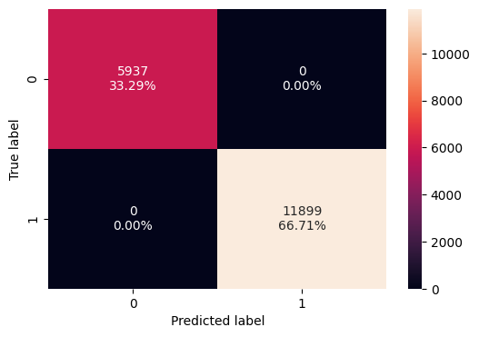

```python
confusion_matrix_sklearn(dtree, X_train, y_train)
```

```python
dtree_model_train_perf=model_performance_classification_sklearn(dtree, X_train, y_train)
print("Training performance \n",dtree_model_train_perf)
```

```
Training performance
    Accuracy  Recall  Precision   F1
0       1.0     1.0        1.0  1.0
```

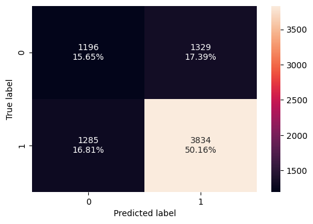

```python
confusion_matrix_sklearn(dtree, X_test, y_test)
```

```python
dtree_model_test_perf=model_performance_classification_sklearn(dtree, X_test, y_test)
print("Testing performance \n",dtree_model_test_perf)
```

```
Testing performance
    Accuracy    Recall  Precision        F1
0  0.658032  0.748974   0.742592  0.745769
```

- The decision tree is overfitting the train dataset and the test dataset seems to not have a good predictive ability to predict visa rejections

Now let's look at some bagging models and Random Forest Classifiers

### Bagging Models

#### Bagging Classifier

```python
bagging = BaggingClassifier(random_state=1)
bagging.fit(X_train,y_train)
```

```
BaggingClassifier(random_state=1)
```

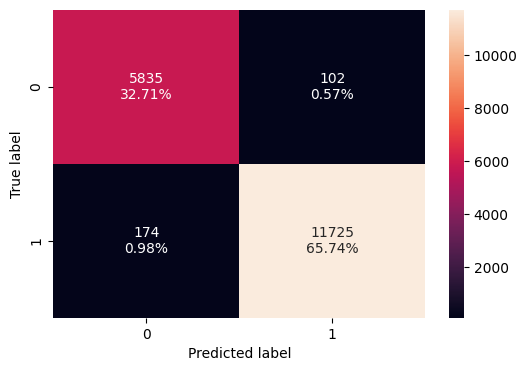

```python
confusion_matrix_sklearn(bagging, X_train, y_train)
```

```python
bagging_model_train_perf=model_performance_classification_sklearn(bagging, X_train, y_train)
print("Training performance \n",bagging_model_train_perf)
```

```
Training performance
    Accuracy    Recall  Precision        F1
0  0.984526  0.985377   0.991376  0.988367
```

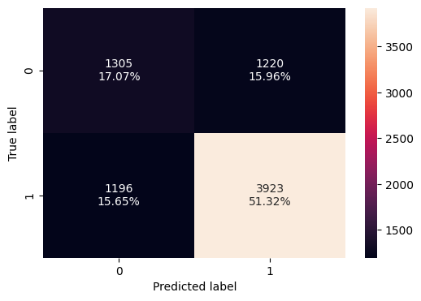

```python
confusion_matrix_sklearn(bagging, X_test, y_test)
```

```python
bagging_model_test_perf=model_performance_classification_sklearn(bagging, X_test, y_test)
print("Testing performance \n",bagging_model_test_perf)
```

```
Testing performance
    Accuracy    Recall  Precision        F1
0  0.683935  0.766361   0.762784  0.764568
```

- Bagging classifier is overfitting on the training set and is performing poorly on the test set in terms of F1 score.

**Bagging Classifier with weighted decision tree**

```python
bagging_wt = BaggingClassifier(base_estimator=DecisionTreeClassifier(criterion='gini',class_weight={0:0.668,1:0.332},random_state=1),random_state=1)
bagging_wt.fit(X_train,y_train)
```

```
BaggingClassifier(base_estimator=DecisionTreeClassifier(class_weight={0: 0.668,
                                                                      1: 0.332},
                                                        random_state=1),
                  random_state=1)
```

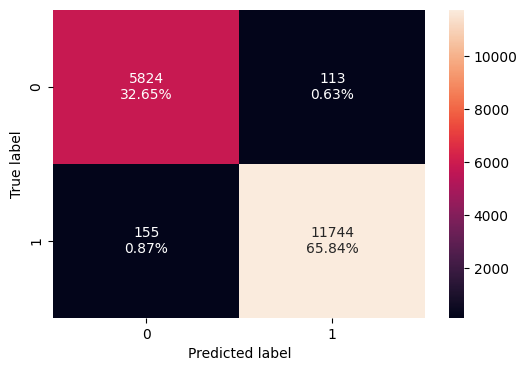

```python
confusion_matrix_sklearn(bagging_wt,X_train,y_train)
```

```python
bagging_wt_model_train_perf=model_performance_classification_sklearn(bagging_wt,X_train,y_train)
print("Training performance \n",bagging_wt_model_train_perf)
```

```
Training performance
    Accuracy    Recall  Precision        F1
0  0.984974  0.986974    0.99047  0.988719
```

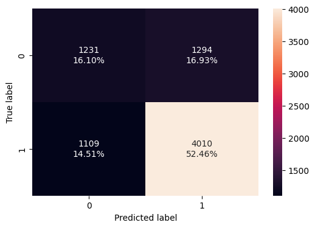

```python
confusion_matrix_sklearn(bagging_wt,X_test,y_test)
```

```python
bagging_wt_model_test_perf=model_performance_classification_sklearn(bagging_wt, X_test, y_test)
print("Testing performance \n",bagging_wt_model_test_perf)
```

```
Testing performance
    Accuracy    Recall  Precision        F1
0  0.685636  0.783356   0.756033  0.769452
```

- Bagging classifier with a weighted decision tree is giving very good accuracy and prediction but is not able to generalize well on test data in terms of F1 score. Seems that the class weighting is not having a generalized impact